# R Performance Study: Summing in Parallel

Daniel Dittenhafer

Friday, November 21, 2014

This performance study compares a simple task, the summation of a vector of integers, using various techniques in the R language including the old standard `for` loop, base R’s vectorized `sum` function, and a `doParallel` package implementation. The `microbenchmark` package is used to perform the timing measurements and visualization of the timing measurements is presented via `ggplot2`.

```r
require(microbenchmark, quietly=TRUE)
require(doParallel, quietly=TRUE)
require(ggplot2, quietly=TRUE)
```

I am running on a 4 core laptop, so I will use 3 cores for this experiment, leaving one for keeping my machine reasonably responsive.

```r
detectedCores <- parallel::detectCores()
registerDoParallel(cores=detectedCores - 1)
print(detectedCores)
```

```
## [1] 4
```

#### Summing with For Loop

The `for` loop to be used in this study is wrapped in the function `forLoopSum` and is defined as follows:

```r
forLoopSum <- function(x)
{
  sum <- 0
  for( a in x){
    sum <- sum + a
  }
  return (sum)
}
```

#### Summing the R Way

The base R `sum` function will be used as is.

```r
sum(x)
```

#### Summing in Parallel

For parallelization, the `doParallel` package will provide the interface to base R’s `parallel` package as described in Weston and Calaway (2014). The split approach used to allocate data amongst various batches is taken from a StackOverflow post (O’Hanlon, 2013). Finally, the base R `foreach` function is used to to iterate over the batches and dispatch them to the parallelizer (Team, 2014).

```r
parallelSum <- function(x) {

  items <- length(x)
  batches <- detectedCores * 4
  batchSets <- split(x, rep(1:batches, length.out=items))

  finalSum <- foreach(b=iter(batchSets, by='row'), .combine="+") %dopar% sum(b)

  return (finalSum)
}
```

#### Performance Experiment

```r
setSize <- c(1, 2, 3, 4, 5, 6, 7, 8)
resultsDF <- data.frame()

# Loop through the set sizes and perform sub-experiment
for(s in setSize) {
  size <- 10 ^ s
  a <- sample(1:20, size, replace=TRUE)

  # Validate
  checkSum <- as.integer(sum(a))
  forSum <- as.integer(forLoopSum(a))
  stopifnot(identical(forSum, checkSum))
  stopifnot(identical(parallelSum(a), checkSum))

  # Run performance test
  results <- microbenchmark::microbenchmark(forLoopSum(a),
                                            sum(a),
                                            parallelSum(a),
                                            times=5, unit="ms")

  # Save results
  agSum <- summary(results)
  agSumPlus <- data.frame(agSum, count = 10 ^ s)

  resultsDF <- rbind(resultsDF, agSumPlus)
}
```

#### Results

The following chart shows the execution times for the various summation techniques.

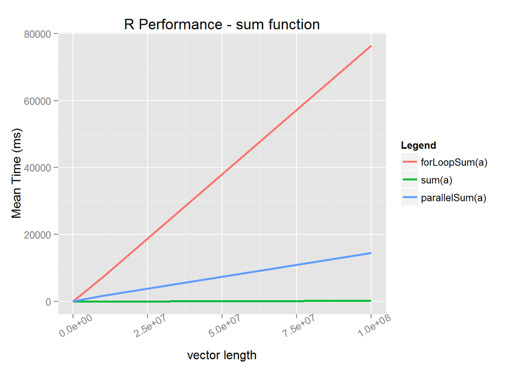

#### Conslusions

As you can see, the base R `sum` function is very scalable compared to a standard `for` loop. A bit surprisingly, batching for parallelization does not improve the execution. Possibly base R is doing something similar under the covers and is optimized for this already, in contrast to my simple batch oriented parallelization which may suffer from non-performant batch determination (maybe the `split` and `rep` functions are eating up time?). This is an area for further investigation.

See the appendix that follows for more detailed statistics for each of the benchmark executions.

#### Appendix

The following table lists the raw microbenchmark statistics from the experiment.

```
##
##
## |expr           |       min|        lq|      mean|    median|        uq|       max| neval| count|
## |:--------------|---------:|---------:|---------:|---------:|---------:|---------:|-----:|-----:|
## |forLoopSum(a)  | 1.630e-02| 1.690e-02| 1.980e-02| 1.750e-02| 2.170e-02| 2.660e-02|     5| 1e+01|
## |sum(a)         | 0.000e+00| 0.000e+00| 1.300e-03| 1.800e-03| 1.800e-03| 3.000e-03|     5| 1e+01|
## |parallelSum(a) | 1.845e+01| 1.886e+01| 1.988e+01| 1.986e+01| 2.026e+01| 2.200e+01|     5| 1e+01|
## |forLoopSum(a)  | 7.000e-02| 7.060e-02| 8.120e-02| 7.300e-02| 9.600e-02| 9.660e-02|     5| 1e+02|
## |sum(a)         | 0.000e+00| 6.000e-04| 1.800e-03| 2.400e-03| 3.000e-03| 3.000e-03|     5| 1e+02|
## |parallelSum(a) | 2.203e+01| 2.304e+01| 2.417e+01| 2.374e+01| 2.530e+01| 2.675e+01|     5| 1e+02|
## |forLoopSum(a)  | 6.481e-01| 6.590e-01| 6.903e-01| 6.759e-01| 6.807e-01| 7.875e-01|     5| 1e+03|
## |sum(a)         | 1.200e-03| 1.800e-03| 3.100e-03| 2.400e-03| 4.800e-03| 5.400e-03|     5| 1e+03|
## |parallelSum(a) | 2.281e+01| 2.283e+01| 2.524e+01| 2.396e+01| 2.688e+01| 2.969e+01|     5| 1e+03|
## |forLoopSum(a)  | 6.507e+00| 6.646e+00| 6.798e+00| 6.897e+00| 6.918e+00| 7.024e+00|     5| 1e+04|
## |sum(a)         | 1.510e-02| 1.930e-02| 1.890e-02| 1.930e-02| 1.990e-02| 2.110e-02|     5| 1e+04|
## |parallelSum(a) | 2.393e+01| 2.442e+01| 2.524e+01| 2.447e+01| 2.564e+01| 2.775e+01|     5| 1e+04|
## |forLoopSum(a)  | 6.802e+01| 7.105e+01| 7.854e+01| 7.364e+01| 8.340e+01| 9.658e+01|     5| 1e+05|
## |sum(a)         | 1.497e-01| 1.750e-01| 2.083e-01| 2.136e-01| 2.142e-01| 2.891e-01|     5| 1e+05|
## |parallelSum(a) | 3.380e+01| 3.694e+01| 4.119e+01| 3.951e+01| 4.597e+01| 4.974e+01|     5| 1e+05|
## |forLoopSum(a)  | 7.043e+02| 7.176e+02| 7.497e+02| 7.291e+02| 7.511e+02| 8.462e+02|     5| 1e+06|
## |sum(a)         | 1.678e+00| 1.681e+00| 1.733e+00| 1.690e+00| 1.729e+00| 1.888e+00|     5| 1e+06|
## |parallelSum(a) | 1.321e+02| 1.382e+02| 1.424e+02| 1.415e+02| 1.462e+02| 1.539e+02|     5| 1e+06|
## |forLoopSum(a)  | 6.949e+03| 7.253e+03| 7.387e+03| 7.465e+03| 7.601e+03| 7.666e+03|     5| 1e+07|
## |sum(a)         | 1.783e+01| 1.789e+01| 1.820e+01| 1.798e+01| 1.803e+01| 1.924e+01|     5| 1e+07|
## |parallelSum(a) | 1.429e+03| 1.462e+03| 1.653e+03| 1.607e+03| 1.858e+03| 1.909e+03|     5| 1e+07|
## |forLoopSum(a)  | 7.306e+04| 7.342e+04| 7.643e+04| 7.425e+04| 7.563e+04| 8.578e+04|     5| 1e+08|
## |sum(a)         | 1.776e+02| 1.801e+02| 1.891e+02| 1.814e+02| 1.926e+02| 2.140e+02|     5| 1e+08|
## |parallelSum(a) | 1.365e+04| 1.384e+04| 1.445e+04| 1.412e+04| 1.461e+04| 1.604e+04|     5| 1e+08|
```

### Source Code

The raw R markdown code used to produce this performance study can be found [on GitHub, in my DataAcqMgmt repository](https://raw.githubusercontent.com/dwdii/DataAcqMgmt/master/Week13/PerformanceStud-RinParallel.Rmd).

#### References

O’Hanlon, S. *Split a vector into three vectors of unequal length in R*. 2013. URL: http://stackoverflow.com/a/18406749.

Team, R. C. *package foreach, version 1.4.1*. R Foundation for Statistical Computing, 2014. URL: http://www.inside-r.org/packages/cran/foreach/docs/foreach.

Weston, S. and R. Calaway. *Getting Started with doParallel and foreach*. 2014. URL: http://cran.r-project.org/web/packages/doParallel/vignettes/gettingstartedParallel.pdf.